# Klasifikasi kualitas air menggunakan metode Decision Tree

```python
#library yang digunakan
import pandas as pd
from sklearn.impute import KNNImputer
from sklearn.preprocessing import MinMaxScaler
from imblearn.over_sampling import SMOTE
from sklearn.model_selection import train_test_split
from sklearn.tree import DecisionTreeClassifier
from sklearn.naive_bayes import GaussianNB
from sklearn.neighbors import KNeighborsClassifier
from sklearn.metrics import accuracy_score, precision_score, recall_score, f1_score, confusion_matrix
import matplotlib.pyplot as plt
import seaborn as sns
```

## dataset

data diperloeh dari kaggle dengan nama ["water quality"](https://www.kaggle.com/datasets/adityakadiwal/water-potability)

```python
data = pd.read_csv("water_potabilitys.csv")
```

## pemahaman data

dataset ini berjumlah 3276 data dan memiliki 9 fitur dengan 1 target yaitu potability, berikut adalah fitur-fitur yang terdapat di dalamnya:

- ph: kandungan pH air (0 hingga 14).
- Hardnes: Kapasitas air untuk mengendapkan sabun dalam mg/L.
- Solid: Total padatan terlarut dalam ppm.
- chloramine: Jumlah Kloramin dalam ppm.
- Sulfate: Jumlah Sulfat yang terlarut dalam mg/L.
- Conductivity: Konduktivitas listrik air dalam μS/cm.
- Organic_carbon: Jumlah karbon organik dalam ppm.
- Trihalomethanes: Jumlah Trihalomethanes dalam μg/L.
- Turbidity: Ukuran sifat air yang memancarkan cahaya di NTU.
- Potability: Menunjukkan apakah air aman untuk dikonsumsi manusia. Dapat diminum -1 dan Tidak dapat diminum -0

```python
data.head()
```

|  | ph | Hardness | Solids | Chloramines | Sulfate | Conductivity | Organic_carbon | Trihalomethanes | Turbidity | Potability |
| --- | --- | --- | --- | --- | --- | --- | --- | --- | --- | --- |
| 0 | NaN | 204.890455 | 20791.318981 | 7.300212 | 368.516441 | 564.308654 | 10.379783 | 86.990970 | 2.963135 | 0 |
| 1 | 3.716080 | 129.422921 | 18630.057858 | 6.635246 | NaN | 592.885359 | 15.180013 | 56.329076 | 4.500656 | 0 |
| 2 | 8.099124 | 224.236259 | 19909.541732 | 9.275884 | NaN | 418.606213 | 16.868637 | 66.420093 | 3.055934 | 0 |
| 3 | 8.316766 | 214.373394 | 22018.417441 | 8.059332 | 356.886136 | 363.266516 | 18.436524 | 100.341674 | 4.628771 | 0 |
| 4 | 9.092223 | 181.101509 | 17978.986339 | 6.546600 | 310.135738 | 398.410813 | 11.558279 | 31.997993 | 4.075075 | 0 |

```python
data.groupby('Potability').size()
```

```
Potability
0    1998
1    1278
dtype: int64
```

```python
data.isnull().sum()
```

```
ph                 491
Hardness             0
Solids               0
Chloramines          0
Sulfate            781
Conductivity         0
Organic_carbon       0
Trihalomethanes    162
Turbidity            0
Potability           0
dtype: int64
```

## Preprocessing data

Proses preprocessing adalah proses untuk membuat dataset menjadi lebih baik, dataset akan dilakukan pembersihan atau pengimputan data dan pemrosesan lainnya seperti mencari outlier, keseimbangan data, normalisasi data dengan tujuan untuk membuat data semakin baik. pada penelitian ini akan dilakukan pengimputan data untuk missing dengan nilai rata-rata dan KNN yang nantinya akan dilakukan perbandingan lebih bagus mana antara data yang diimput dengan nilai rata-rata atau KNN, kemudian juga akan dilakukan normalisasi data dengan metode minmax kemudian akan dilakukan penyeimbangan data dengan metode SMOTE

```python
X = data.drop(columns=['Potability'])
y = data['Potability']
```

### Imputasi Missing value

proses untuk menginput nilai yang kosong atau hilang, proses dapat dilakukan oleh beberapa metode,seperti pada penilitian ini teradpat 2 metode yang digunakna yaitu mengisi nilai kosong dengan nilai rata rata dan mengisi nilai kosong dengan metode knn.

#### rata-rata

nilai kosong akan diisin oleh nilai rata-rata pada fitur yang memiliki nilai kosong

#### knn imputasi

nilai kosong akan diisi dengan metode knn imputasi, dimana program akan mencari tetangga terdekat, pada penelitian ini yang bagus yaitu menggunakan 10 tetangga terdekat(percobaan manual), kemudian tetangga terdekat tersebut akan di cari nilai rata-ratanya dan nilai kosong akan diisikan oleh nilai rata-rata dari tetangga tersebut.  
rumus knn untuk imputasi:

$$ X = \frac{1}{K} \sum_{k=1}^{K} X_{k} $$

```python
Xrata = X.fillna(X.mean())
imputer = KNNImputer(n_neighbors=10)
Xknn = pd.DataFrame(imputer.fit_transform(X), columns=X.columns)
```

### normalisasi data

normalisasi data adalah proses membuat dataset yang awalnya memiliki rentang nilai jauh berbeda menjadi rentang nilai yang sama, metode yang digunakan di sini yaitu min-max scaler dimana data akan di ubah menjadi nilai dengan rentang 1-0.

```python
scaler = MinMaxScaler(feature_range=(0, 1))
Xrata= pd.DataFrame(scaler.fit_transform(Xrata), columns=X.columns)
Xknn= pd.DataFrame(scaler.fit_transform(Xknn), columns=X.columns)
```

#### penyeimbangan data

penyeimbangan data adalah proses untuk membuat data menjadi seimbang, pada penelitian dataset yang digunakan memiliki kelas 0 sebanyak 0.61 dan kelas 1 sebanyak 0.39 maka dari itu diperlukan penanganan dalam ketidak seimbangan data, begitupun karena decision tree adalah metode yang sensitif terhadap data tidak seimbang.  
langkah-langkah =

- mencari tetangga terderat
- membuat data sintesis dengan rumus $ x_{\text{sintetik}} = x_i + \lambda \cdot (x_k - x_i) $

```python
smote = SMOTE(random_state=42)
Xrata, yrata = smote.fit_resample(Xrata, y)
Xknn, yknn = smote.fit_resample(Xknn, y)
```

## Pemodelan

### spliting data

```python
X_train, X_test, y_train, y_test = train_test_split(Xknn, yknn, test_size=0.2, random_state=42)
X_train, X_test, y_train, y_test = train_test_split(Xrata, yrata, test_size=0.2, random_state=42)
```

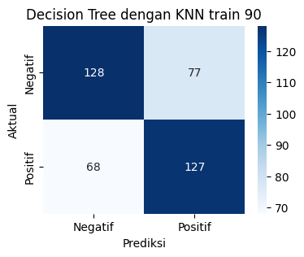

```
Decision Tree dengan KNN train 90
Akurasi: 0.64
Precision: 0.62
Recall: 0.65
F1 Score: 0.64
```

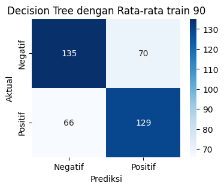

```
Decision Tree dengan Rata-rata train 90
Akurasi: 0.66
Precision: 0.65
Recall: 0.66
F1 Score: 0.65
```

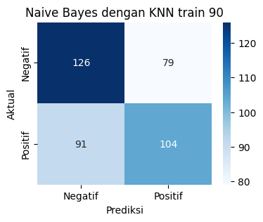

```
Naive Bayes dengan KNN train 90
Akurasi: 0.57
Precision: 0.57
Recall: 0.53
F1 Score: 0.55
```

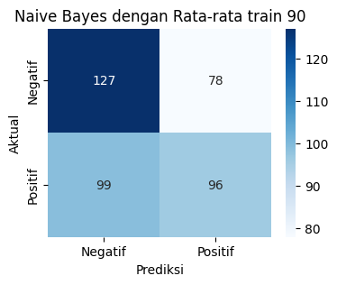

```
Naive Bayes dengan Rata-rata train 90
Akurasi: 0.56
Precision: 0.55
Recall: 0.49
F1 Score: 0.52
```

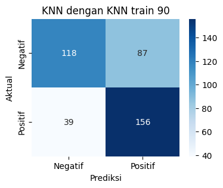

```
KNN dengan KNN train 90
Akurasi: 0.69
Precision: 0.64
Recall: 0.80
F1 Score: 0.71
```

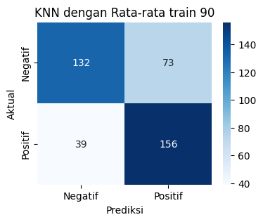

```
KNN dengan Rata-rata train 90
Akurasi: 0.72
Precision: 0.68
Recall: 0.80
F1 Score: 0.74
```

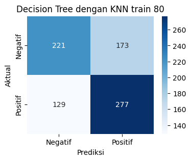

```
Decision Tree dengan KNN train 80
Akurasi: 0.62
Precision: 0.62
Recall: 0.68
F1 Score: 0.65
```

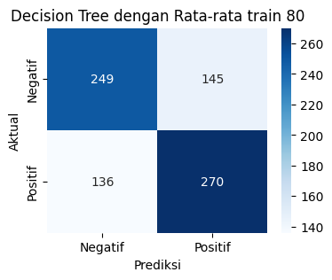

```
Decision Tree dengan Rata-rata train 80
Akurasi: 0.65
Precision: 0.65
Recall: 0.67
F1 Score: 0.66
```

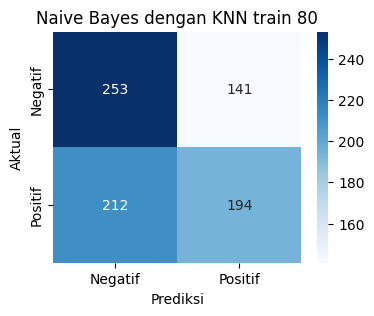

```
Naive Bayes dengan KNN train 80
Akurasi: 0.56
Precision: 0.58
Recall: 0.48
F1 Score: 0.52
```

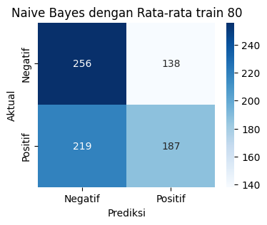

```
Naive Bayes dengan Rata-rata train 80
Akurasi: 0.55
Precision: 0.58
Recall: 0.46
F1 Score: 0.51
```

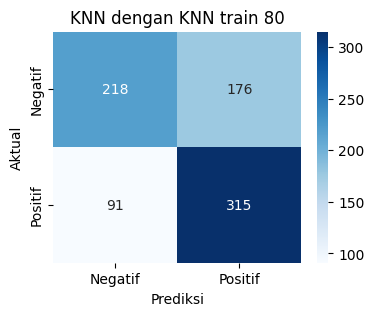

```
KNN dengan KNN train 80
Akurasi: 0.67
Precision: 0.64
Recall: 0.78
F1 Score: 0.70
```

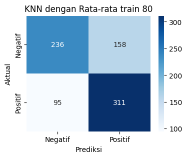

```
KNN dengan Rata-rata train 80
Akurasi: 0.68
Precision: 0.66
Recall: 0.77
F1 Score: 0.71
```

[6 more figures not shown]

```
KNN dengan Rata-rata train 70
Akurasi: 0.66
Precision: 0.65
Recall: 0.72
F1 Score: 0.68

Perbandingan Model:
                                      Model   Akurasi  Precision    Recall  \
0         Decision Tree dengan KNN train 90  0.637500   0.622549  0.651282
1   Decision Tree dengan Rata-rata train 90  0.660000   0.648241  0.661538
2           Naive Bayes dengan KNN train 90  0.575000   0.568306  0.533333
3     Naive Bayes dengan Rata-rata train 90  0.557500   0.551724  0.492308
4                   KNN dengan KNN train 90  0.685000   0.641975  0.800000
5             KNN dengan Rata-rata train 90  0.720000   0.681223  0.800000
6         Decision Tree dengan KNN train 80  0.622500   0.615556  0.682266
```

[output cut: 31 more lines]

```python
def evaluate_model(X, y, model, title, test_size):
    X_train, X_test, y_train, y_test = train_test_split(X, y, test_size=test_size, random_state=42)
    model.fit(X_train, y_train)
    y_pred = model.predict(X_test)

    # Menghitung metrik evaluasi
    accuracy = accuracy_score(y_test, y_pred)
    precision = precision_score(y_test, y_pred)
    recall = recall_score(y_test, y_pred)
    f1 = f1_score(y_test, y_pred)

    # Menampilkan confusion matrix
    conf_matrix = confusion_matrix(y_test, y_pred)
    plt.figure(figsize=(4, 3))
    sns.heatmap(conf_matrix, annot=True, fmt='d', cmap='Blues',
                xticklabels=['Negatif', 'Positif'], yticklabels=['Negatif', 'Positif'])
    plt.xlabel('Prediksi')
    plt.ylabel('Aktual')
    plt.title(title)
    plt.show()

    # Menampilkan hasil metrik evaluasi
    print(title)
    print(f'Akurasi: {accuracy:.2f}')
    print(f'Precision: {precision:.2f}')
    print(f'Recall: {recall:.2f}')
    print(f'F1 Score: {f1:.2f}')

    return accuracy, precision, recall, f1

# Data dan model untuk evaluasi
results = []
models = [
    # menggunakan train 90 dan test 10
    ("Decision Tree dengan KNN train 90", DecisionTreeClassifier(random_state=42), Xknn, yknn, 0.1),
    ("Decision Tree dengan Rata-rata train 90", DecisionTreeClassifier(random_state=42), Xrata, yrata, 0.1),
    ("Naive Bayes dengan KNN train 90", GaussianNB(), Xknn, yknn, 0.1),
    ("Naive Bayes dengan Rata-rata train 90", GaussianNB(), Xrata, yrata, 0.1),
    ("KNN dengan KNN train 90", KNeighborsClassifier(n_neighbors=3), Xknn, yknn, 0.1),
    ("KNN dengan Rata-rata train 90", KNeighborsClassifier(n_neighbors=3), Xrata, yrata, 0.1),
    # menggunakan train 80 dan test 20
    ("Decision Tree dengan KNN train 80", DecisionTreeClassifier(random_state=42), Xknn, yknn, 0.2),
    ("Decision Tree dengan Rata-rata train 80", DecisionTreeClassifier(random_state=42), Xrata, yrata, 0.2),
    ("Naive Bayes dengan KNN train 80", GaussianNB(), Xknn, yknn, 0.2),
    ("Naive Bayes dengan Rata-rata train 80", GaussianNB(), Xrata, yrata, 0.2),
    ("KNN dengan KNN train 80", KNeighborsClassifier(n_neighbors=3), Xknn, yknn, 0.2),
    ("KNN dengan Rata-rata train 80", KNeighborsClassifier(n_neighbors=3), Xrata, yrata, 0.2),
    # menggunakan train 70 dan test 30
    ("Decision Tree dengan KNN train 70", DecisionTreeClassifier(random_state=42), Xknn, yknn, 0.3),
    ("Decision Tree dengan Rata-rata train 70", DecisionTreeClassifier(random_state=42), Xrata, yrata, 0.3),
    ("Naive Bayes dengan KNN train 70", GaussianNB(), Xknn, yknn, 0.3),
    ("Naive Bayes dengan Rata-rata train 70", GaussianNB(), Xrata, yrata, 0.3),
    ("KNN dengan KNN train 70", KNeighborsClassifier(n_neighbors=3), Xknn, yknn, 0.3),
    ("KNN dengan Rata-rata train 70", KNeighborsClassifier(n_neighbors=3), Xrata, yrata, 0.3)
]

# Loop untuk evaluasi setiap model
for title, model, X, y, test_size in models:
    accuracy, precision, recall, f1 = evaluate_model(X, y, model, title, test_size)
    results.append((title, accuracy, precision, recall, f1))

perbangingan = pd.DataFrame(results, columns=["Model", "Akurasi", "Precision", "Recall", "F1 Score"])

# Menampilkan hasil perbandingan
print("\nPerbandingan Model:")
print(perbangingan)
```